# IODS course project

## MCA with Tea dataset

MCA (multiple correspondence analysis) is an extensiong of summarizing and visualizing datasets with multiple categorical variables. We want to see if there are similarities to the observations from 6 different varibles below.

```r
library(FactoMineR)
```

```r
library(ggplot2)
library(tidyr)

#Loading the data
data("tea")

#Exploring the data set
str(tea)
```

```
## 'data.frame':    300 obs. of  36 variables:
##  $ breakfast       : Factor w/ 2 levels "breakfast","Not.breakfast": 1 1 2 2 1 2 1 2 1 1 ...
##  $ tea.time        : Factor w/ 2 levels "Not.tea time",..: 1 1 2 1 1 1 2 2 2 1 ...
##  $ evening         : Factor w/ 2 levels "evening","Not.evening": 2 2 1 2 1 2 2 1 2 1 ...
##  $ lunch           : Factor w/ 2 levels "lunch","Not.lunch": 2 2 2 2 2 2 2 2 2 2 ...
##  $ dinner          : Factor w/ 2 levels "dinner","Not.dinner": 2 2 1 1 2 1 2 2 2 2 ...
##  $ always          : Factor w/ 2 levels "always","Not.always": 2 2 2 2 1 2 2 2 2 2 ...
##  $ home            : Factor w/ 2 levels "home","Not.home": 1 1 1 1 1 1 1 1 1 1 ...
##  $ work            : Factor w/ 2 levels "Not.work","work": 1 1 2 1 1 1 1 1 1 1 ...
##  $ tearoom         : Factor w/ 2 levels "Not.tearoom",..: 1 1 1 1 1 1 1 1 1 2 ...
##  $ friends         : Factor w/ 2 levels "friends","Not.friends": 2 2 1 2 2 2 1 2 2 2 ...
##  $ resto           : Factor w/ 2 levels "Not.resto","resto": 1 1 2 1 1 1 1 1 1 1 ...
##  $ pub             : Factor w/ 2 levels "Not.pub","pub": 1 1 1 1 1 1 1 1 1 1 ...
##  $ Tea             : Factor w/ 3 levels "black","Earl Grey",..: 1 1 2 2 2 2 2 1 2 1 ...
##  $ How             : Factor w/ 4 levels "alone","lemon",..: 1 3 1 1 1 1 1 3 3 1 ...
```

[output cut: 22 more lines]

```r
dim(tea)
```

```
## [1] 300  36
```

We can see here that there are 300 observations with 36 variables.

```r
#36 variables is a lot, let us choose couple to examine closer


#Column names to keep in the data set
keep_columns <- c("dinner", "home", "work", "friends", "breakfast", "lunch")

#Selecting the 'keep_columns' to create a new data set
tea_time <- dplyr::select(tea, one_of(keep_columns))

#The summaries and structure of the data
summary(tea_time)
```

```
##         dinner          home           work            friends
##  dinner    : 21   home    :291   Not.work:213   friends    :196
##  Not.dinner:279   Not.home:  9   work    : 87   Not.friends:104
##          breakfast         lunch
##  breakfast    :144   lunch    : 44
##  Not.breakfast:156   Not.lunch:256
```

```r
str(tea_time)
```

```
## 'data.frame':    300 obs. of  6 variables:
##  $ dinner   : Factor w/ 2 levels "dinner","Not.dinner": 2 2 1 1 2 1 2 2 2 2 ...
##  $ home     : Factor w/ 2 levels "home","Not.home": 1 1 1 1 1 1 1 1 1 1 ...
##  $ work     : Factor w/ 2 levels "Not.work","work": 1 1 2 1 1 1 1 1 1 1 ...
##  $ friends  : Factor w/ 2 levels "friends","Not.friends": 2 2 1 2 2 2 1 2 2 2 ...
##  $ breakfast: Factor w/ 2 levels "breakfast","Not.breakfast": 1 1 2 2 1 2 1 2 1 1 ...
##  $ lunch    : Factor w/ 2 levels "lunch","Not.lunch": 2 2 2 2 2 2 2 2 2 2 ...
```

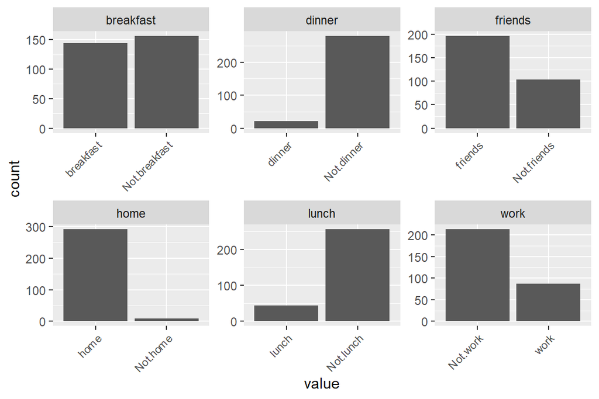

```r
#Visualization of the data set
gather(tea_time) %>% ggplot(aes(value)) + facet_wrap("key", scales = "free") + geom_bar() + theme(axis.text.x = element_text(angle = 45, hjust = 1, size = 8))
```

```r
#Multiple correspondence analysis
mca <- MCA(tea_time, graph = FALSE)
```

Here I have only take 6 variables including breakfast, lunch, dinner, home, friends and work. We see people drink tea at breakfast and not breakfast. Also, we see that not drinking at dinner and lunch is most often. People like to drink tea at home and with friends. Most people dont drink tea at work.

```r
#Summary of the model
summary(mca)
```

```
##
## Call:
## MCA(X = tea_time, graph = FALSE)
##
##
## Eigenvalues
##                        Dim.1   Dim.2   Dim.3   Dim.4   Dim.5   Dim.6
## Variance               0.225   0.195   0.168   0.158   0.140   0.115
## % of var.             22.471  19.463  16.777  15.758  14.042  11.489
## Cumulative % of var.  22.471  41.934  58.711  74.469  88.511 100.000
##
## Individuals (the 10 first)
##                  Dim.1    ctr   cos2    Dim.2    ctr   cos2    Dim.3    ctr
## 1             |  0.166  0.041  0.045 | -0.681  0.794  0.761 |  0.273  0.148
## 2             |  0.166  0.041  0.045 | -0.681  0.794  0.761 |  0.273  0.148
## 3             |  0.582  0.503  0.117 |  0.768  1.010  0.203 | -0.267  0.141
## 4             |  1.292  2.475  0.599 |  0.157  0.042  0.009 | -0.150  0.045
## 5             |  0.166  0.041  0.045 | -0.681  0.794  0.761 |  0.273  0.148
## 6             |  1.292  2.475  0.599 |  0.157  0.042  0.009 | -0.150  0.045
## 7             | -0.159  0.037  0.066 | -0.261  0.117  0.178 | -0.177  0.062
## 8             |  0.510  0.386  0.447 | -0.214  0.078  0.078 |  0.094  0.018
## 9             |  0.166  0.041  0.045 | -0.681  0.794  0.761 |  0.273  0.148
## 10            |  0.166  0.041  0.045 | -0.681  0.794  0.761 |  0.273  0.148
##                 cos2
## 1              0.122 |
## 2              0.122 |
## 3              0.025 |
## 4              0.008 |
## 5              0.122 |
## 6              0.008 |
## 7              0.082 |
## 8              0.015 |
## 9              0.122 |
## 10             0.122 |
##
## Categories (the 10 first)
##                   Dim.1     ctr    cos2  v.test     Dim.2     ctr    cos2
## dinner        |   2.067  22.177   0.322   9.805 |   0.913   4.998   0.063
## Not.dinner    |  -0.156   1.669   0.322  -9.805 |  -0.069   0.376   0.063
## home          |  -0.022   0.036   0.016  -2.189 |  -0.097   0.788   0.307
```

[output cut: 12 more lines]

```
## Not.work       -3.965 |  -0.238   3.982   0.138  -6.429 |
## work            3.965 |   0.582   9.749   0.138   6.429 |
## friends         9.138 |  -0.383   9.535   0.277  -9.098 |
## Not.friends    -9.138 |   0.722  17.969   0.277   9.098 |
## breakfast     -10.682 |   0.229   2.491   0.048   3.797 |
## Not.breakfast  10.682 |  -0.211   2.300   0.048  -3.797 |
##
## Categorical variables (eta2)
##                 Dim.1 Dim.2 Dim.3
## dinner        | 0.322 0.063 0.023 |
## home          | 0.016 0.307 0.510 |
## work          | 0.246 0.053 0.138 |
## friends       | 0.193 0.279 0.277 |
## breakfast     | 0.239 0.382 0.048 |
## lunch         | 0.332 0.085 0.010 |
```

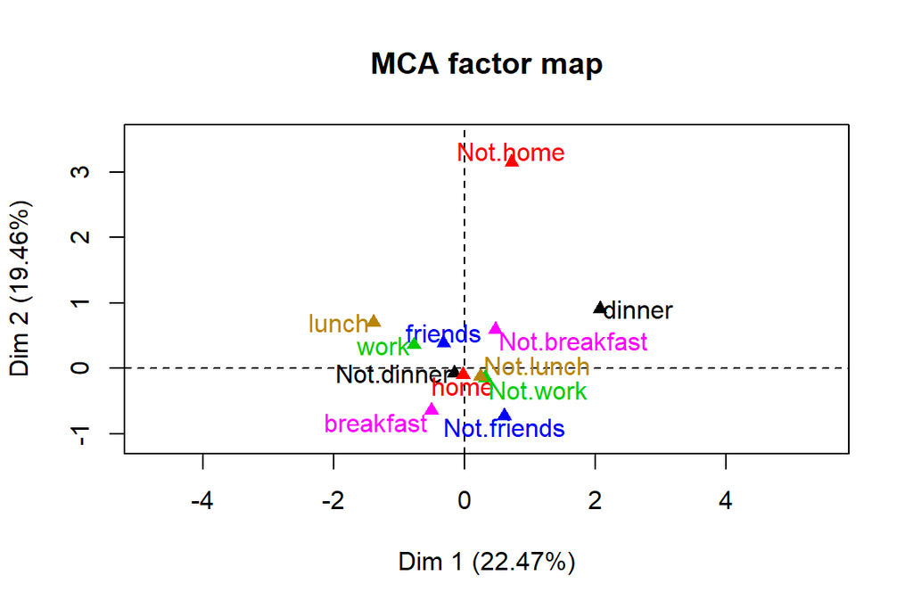

```r
#Visualization of MCA
plot(mca, invisible=c("ind"), habillage = "quali",graph.type = "classic")
```

# Chapter 6

For this week we will load two datasets in wide format and convert them to long format. We will then perform analysis on the long formatted dataset.

## Analysis of RATS data

We now will load the RATS data.

```r
library(reshape2)
```

```r
library(ggplot2)
library(dplyr)
library(tidyr)


RATS <- read.table("https://raw.githubusercontent.com/KimmoVehkalahti/MABS/master/Examples/data/rats.txt", header = TRUE, sep = '\t')

# Factor variables ID and Group
RATS$ID <- factor(RATS$ID)
RATS$Group <- factor(RATS$Group)

str(RATS)
```

```
## 'data.frame':    16 obs. of  13 variables:
##  $ ID   : Factor w/ 16 levels "1","2","3","4",..: 1 2 3 4 5 6 7 8 9 10 ...
##  $ Group: Factor w/ 3 levels "1","2","3": 1 1 1 1 1 1 1 1 2 2 ...
##  $ WD1  : int  240 225 245 260 255 260 275 245 410 405 ...
##  $ WD8  : int  250 230 250 255 260 265 275 255 415 420 ...
##  $ WD15 : int  255 230 250 255 255 270 260 260 425 430 ...
##  $ WD22 : int  260 232 255 265 270 275 270 268 428 440 ...
##  $ WD29 : int  262 240 262 265 270 275 273 270 438 448 ...
##  $ WD36 : int  258 240 265 268 273 277 274 265 443 460 ...
##  $ WD43 : int  266 243 267 270 274 278 276 265 442 458 ...
##  $ WD44 : int  266 244 267 272 273 278 271 267 446 464 ...
##  $ WD50 : int  265 238 264 274 276 284 282 273 456 475 ...
##  $ WD57 : int  272 247 268 273 278 279 281 274 468 484 ...
##  $ WD64 : int  278 245 269 275 280 281 284 278 478 496 ...
```

```r
View(RATS)
```

## Change to long format

```r
RATSL <- RATS %>%
  gather(key = WD, value = Weight, -ID, -Group) %>%
  mutate(Time = as.integer(substr(WD,3,4)))

str(RATSL)
```

```
## 'data.frame':    176 obs. of  5 variables:
##  $ ID    : Factor w/ 16 levels "1","2","3","4",..: 1 2 3 4 5 6 7 8 9 10 ...
##  $ Group : Factor w/ 3 levels "1","2","3": 1 1 1 1 1 1 1 1 2 2 ...
##  $ WD    : chr  "WD1" "WD1" "WD1" "WD1" ...
##  $ Weight: int  240 225 245 260 255 260 275 245 410 405 ...
##  $ Time  : int  1 1 1 1 1 1 1 1 1 1 ...
```

As we can see, the long data is easier to work with. From personal experience, I have had difficulty being able to understand wide data and edit it. There are two many columns and it isn’t easy to filter. The long data set puts treatments, dates and other categories all in one column so that you have fewer columns and just have each data point (obersvation there easier to see.

This data is from a nutrition study with 9 different weeks on three groups. Having this data in long format allows for better analysis between the weeks and groups.

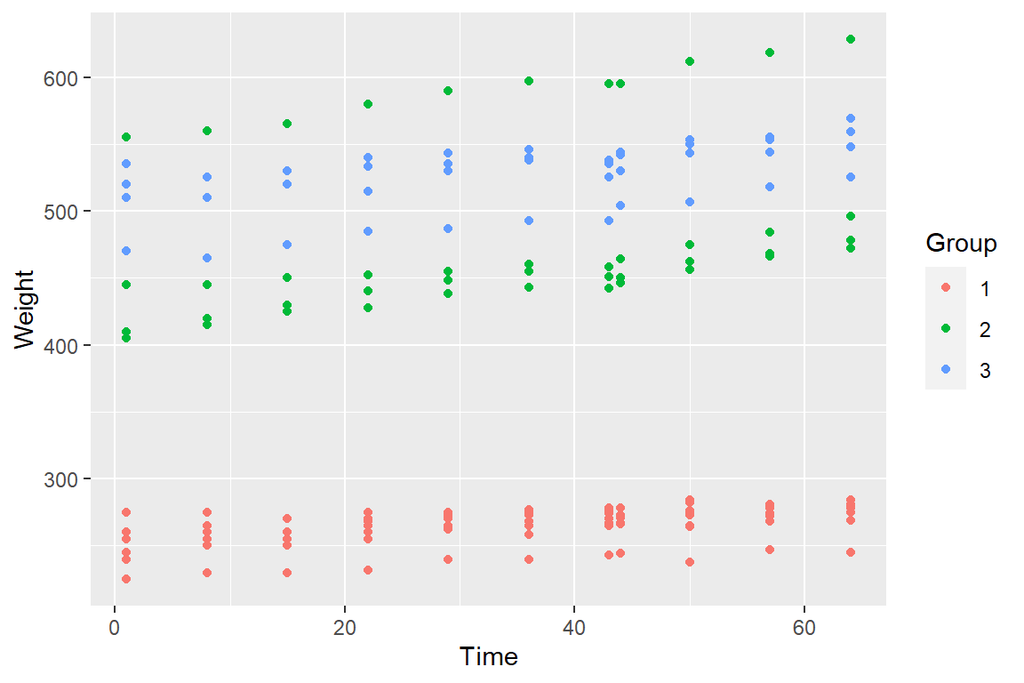

```r
# Draw the plot
ggplot(RATSL, aes(x = Time, y = Weight, linetype = Group)) +
  geom_point(aes(col = Group))
```

Here we see the plot of the groups shown in different colors.

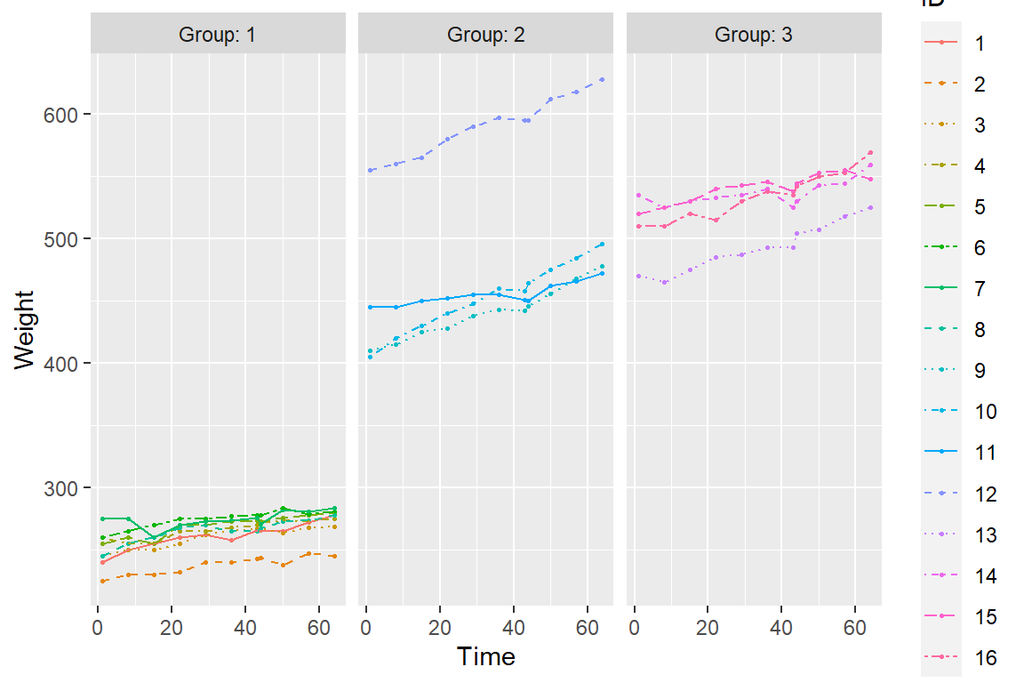

```r
ggplot(RATSL, aes(x = Time, y = Weight, linetype = ID, color = ID)) +
  geom_point(size = 0.5) +
  geom_line(aes(group = ID)) +
  scale_linetype_manual(values = rep(1:10, times=4)) +
  facet_grid(. ~ Group, labeller = label_both) +
  scale_y_continuous(limits = c(min(RATSL$Weight), max(RATSL$Weight)))
```

Here I have plotted each group separately with the individuals with a seperate line.

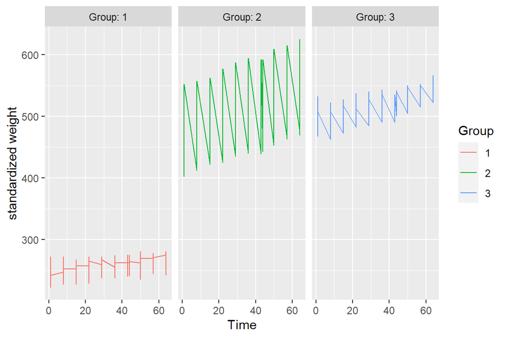

```r
# Standardise the variable bprs
RATSL <- RATSL %>%
  group_by(Time) %>%
  mutate(stdweight = (Weight) - mean(Weight)/sd(Weight) ) %>%
  ungroup()



# Plot again with the standardised bprs
ggplot(RATSL, aes(x = Time, y = stdweight, col = Group)) +
  geom_line() +
  scale_linetype_manual(values = rep(1:10, times=4)) +
  facet_grid(. ~ Group, labeller = label_both) +
  scale_y_continuous(name = "standardized weight")
```

```r
# Number of weeks, baseline (week 0) included
n <- RATSL$Time %>% unique() %>% length()

# Summary data with mean and standard error of bprs by treatment and week
RATSS <- RATSL %>%
  group_by(Group, Time) %>%
  summarise( mean = mean(Weight), se = sd(Weight)/sqrt(n) ) %>%
  ungroup()
```

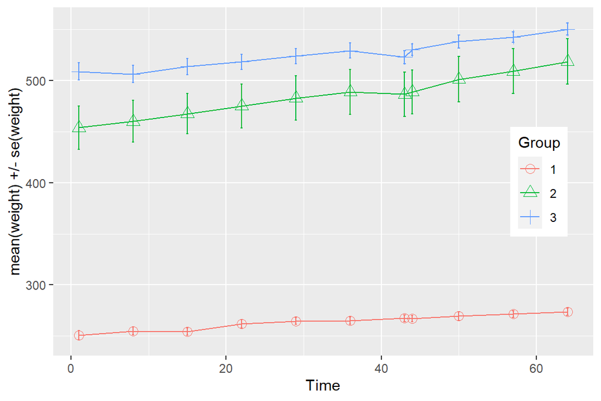

```r
# Plot the mean profiles
ggplot(RATSS, aes(x = Time, y = mean, col = Group, shape = Group)) +
  geom_line() +
  scale_linetype_manual(values = c(1,2,3)) +
  geom_point(size=3) +
  scale_shape_manual(values = c(1,2,3)) +
  geom_errorbar(aes(ymin = mean - se, ymax = mean + se), width=0.3) +
  theme(legend.position = c(0.9,0.5)) +
  scale_y_continuous(name = "mean(weight) +/- se(weight)")
```

Here we are able to see that groups 2 and 3 are gaining weight over time while the group 1 seems to not gain much at all.

```r
# Create a summary data by treatment and subject with mean as the summary variable (ignoring baseline week 0).
RATSSbox <- RATSL %>%
   group_by(Group, ID) %>%
  summarise( mean=mean(Weight) ) %>%
  ungroup()
```

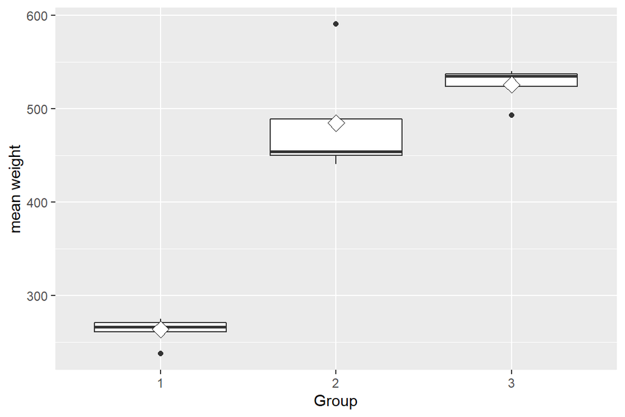

```r
# Draw a boxplot of the mean versus treatment
ggplot(RATSSbox, aes(x = Group, y = mean)) +
  geom_boxplot() +
  stat_summary(fun.y = "mean", geom = "point", shape=23, size=4, fill = "white") +
  scale_y_continuous(name = "mean weight")
```

```r
# Create a new data by filtering the outlier and adjust the ggplot code the draw the plot again with the new data
RATSSbox1 <- RATSSbox %>%
  filter(mean < 540)
```

```r
# Add the baseline from the original data as a new variable to the summary data
RATSSbox2<- RATSSbox %>%
  mutate(baseline = RATS$WD1)




# Fit the linear model with the mean as the response
fit <- lm(mean ~ baseline + Group, data = RATSSbox2)

# Compute the analysis of variance table for the fitted model with anova()
anova(fit)
```

```
## Analysis of Variance Table
##
## Response: mean
##           Df Sum Sq Mean Sq   F value    Pr(>F)
## baseline   1 252125  252125 2237.0655 5.217e-15 ***
## Group      2    726     363    3.2219   0.07586 .
## Residuals 12   1352     113
## ---
## Signif. codes:  0 '***' 0.001 '**' 0.01 '*' 0.05 '.' 0.1 ' ' 1
```

## Analysis of BPRS Data

```r
# Read the BPRS data
BPRS <- read.table("https://raw.githubusercontent.com/KimmoVehkalahti/MABS/master/Examples/data/BPRS.txt", sep  =" ", header = T)

# Look at the (column) names of BPRS
names(BPRS)
```

```
##  [1] "treatment" "subject"   "week0"     "week1"     "week2"     "week3"
##  [7] "week4"     "week5"     "week6"     "week7"     "week8"
```

```r
# Look at the structure of BPRS
str(BPRS)
```

```
## 'data.frame':    40 obs. of  11 variables:
##  $ treatment: int  1 1 1 1 1 1 1 1 1 1 ...
##  $ subject  : int  1 2 3 4 5 6 7 8 9 10 ...
##  $ week0    : int  42 58 54 55 72 48 71 30 41 57 ...
##  $ week1    : int  36 68 55 77 75 43 61 36 43 51 ...
##  $ week2    : int  36 61 41 49 72 41 47 38 39 51 ...
##  $ week3    : int  43 55 38 54 65 38 30 38 35 55 ...
##  $ week4    : int  41 43 43 56 50 36 27 31 28 53 ...
##  $ week5    : int  40 34 28 50 39 29 40 26 22 43 ...
##  $ week6    : int  38 28 29 47 32 33 30 26 20 43 ...
##  $ week7    : int  47 28 25 42 38 27 31 25 23 39 ...
##  $ week8    : int  51 28 24 46 32 25 31 24 21 32 ...
```

```r
# print out summaries of the variables
summary(BPRS)
```

```
##    treatment      subject          week0           week1           week2
##  Min.   :1.0   Min.   : 1.00   Min.   :24.00   Min.   :23.00   Min.   :26.0
##  1st Qu.:1.0   1st Qu.: 5.75   1st Qu.:38.00   1st Qu.:35.00   1st Qu.:32.0
##  Median :1.5   Median :10.50   Median :46.00   Median :41.00   Median :38.0
##  Mean   :1.5   Mean   :10.50   Mean   :48.00   Mean   :46.33   Mean   :41.7
##  3rd Qu.:2.0   3rd Qu.:15.25   3rd Qu.:58.25   3rd Qu.:54.25   3rd Qu.:49.0
##  Max.   :2.0   Max.   :20.00   Max.   :78.00   Max.   :95.00   Max.   :75.0
##      week3           week4           week5           week6           week7
##  Min.   :24.00   Min.   :20.00   Min.   :20.00   Min.   :19.00   Min.   :18.0
##  1st Qu.:29.75   1st Qu.:28.00   1st Qu.:26.00   1st Qu.:22.75   1st Qu.:23.0
##  Median :36.50   Median :34.50   Median :30.50   Median :28.50   Median :30.0
##  Mean   :39.15   Mean   :36.35   Mean   :32.55   Mean   :31.23   Mean   :32.2
##  3rd Qu.:44.50   3rd Qu.:43.00   3rd Qu.:38.00   3rd Qu.:37.00   3rd Qu.:38.0
##  Max.   :76.00   Max.   :66.00   Max.   :64.00   Max.   :64.00   Max.   :62.0
##      week8
##  Min.   :20.00
##  1st Qu.:22.75
##  Median :28.00
##  Mean   :31.43
##  3rd Qu.:35.25
##  Max.   :75.00
```

## Convert to long format

```r
# Factor treatment & subject
BPRS$treatment <- factor(BPRS$treatment)
BPRS$subject <- factor(BPRS$subject)


# Convert to long form
BPRSL <-  BPRS %>% gather(key = weeks, value = bprs, -treatment, -subject)

# Extract the week number
BPRSL <-  BPRSL %>% mutate(week = as.integer(substr(weeks,5,5)))

str(BPRSL)
```

```
## 'data.frame':    360 obs. of  5 variables:
##  $ treatment: Factor w/ 2 levels "1","2": 1 1 1 1 1 1 1 1 1 1 ...
##  $ subject  : Factor w/ 20 levels "1","2","3","4",..: 1 2 3 4 5 6 7 8 9 10 ...
##  $ weeks    : chr  "week0" "week0" "week0" "week0" ...
##  $ bprs     : int  42 58 54 55 72 48 71 30 41 57 ...
##  $ week     : int  0 0 0 0 0 0 0 0 0 0 ...
```

```r
View(BPRSL)
```

As discussed under the RATS data with long conversion, this BPRS data is also better analyzed after long conversion. It is easier to group the individuals responses when have the weeks in a different format.

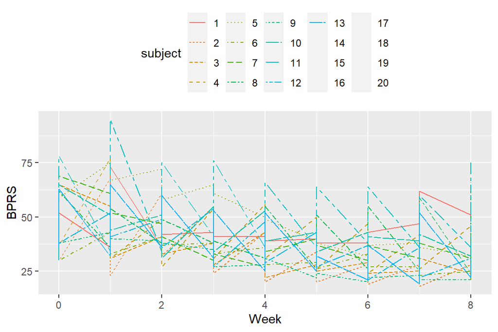

```r
## Plot the data
ggplot(BPRSL, aes(x = week, y = bprs, col = subject)) +
  geom_line(aes(linetype =subject)) +
  scale_x_continuous(name = "Week") +
  scale_y_continuous(name = "BPRS") +
  theme(legend.position = "top")
```

From the plot above we can see the longitudinal data among the weeks and individuals. We will now run a regression linear model.

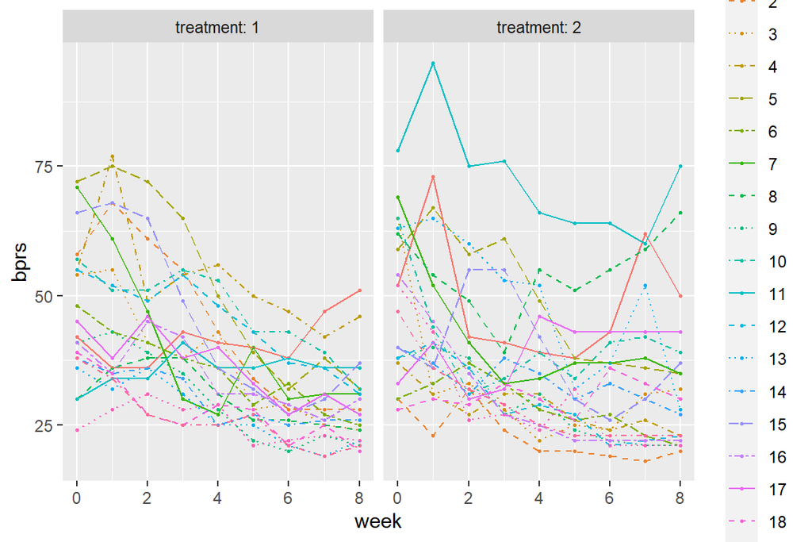

```r
ggplot(BPRSL, aes(x = week, y = bprs, linetype = subject, col = subject)) +
  geom_point(size = 0.5) +
  geom_line() +
  scale_linetype_manual(values = rep(1:10, times=4)) +
  facet_grid(. ~ treatment, labeller = label_both) +
  scale_y_continuous(limits = c(min(BPRSL$bprs), max(BPRSL$bprs)))
```

From the above graphs we can see the longitudinal data over time with each treatments. We see the variation with all of the subjects.

```r
BPRS_reg <- lm(bprs ~ week + treatment, data = BPRSL)

# print out a summary of the model
summary(BPRS_reg)
```

```
##
## Call:
## lm(formula = bprs ~ week + treatment, data = BPRSL)
##
## Residuals:
##     Min      1Q  Median      3Q     Max
## -22.454  -8.965  -3.196   7.002  50.244
##
## Coefficients:
##             Estimate Std. Error t value Pr(>|t|)
## (Intercept)  46.4539     1.3670  33.982   <2e-16 ***
## week         -2.2704     0.2524  -8.995   <2e-16 ***
## treatment2    0.5722     1.3034   0.439    0.661
## ---
## Signif. codes:  0 '***' 0.001 '**' 0.01 '*' 0.05 '.' 0.1 ' ' 1
##
## Residual standard error: 12.37 on 357 degrees of freedom
## Multiple R-squared:  0.1851, Adjusted R-squared:  0.1806
## F-statistic: 40.55 on 2 and 357 DF,  p-value: < 2.2e-16
```

We can see that there are statistical differences between the weeks. The p-value is very low meaning a high statistical difference.

### Linear Model and Random inercept model

```r
#install.packages('lme4')
library('lme4')
# Create a random intercept model
BPRS_ref <- lmer(bprs ~ week + treatment + (1| subject), data = BPRSL, REML = FALSE)

# Print the summary of the model
summary(BPRS_ref)
```

```
## Linear mixed model fit by maximum likelihood  ['lmerMod']
## Formula: bprs ~ week + treatment + (1 | subject)
##    Data: BPRSL
##
##      AIC      BIC   logLik deviance df.resid
##   2748.7   2768.1  -1369.4   2738.7      355
##
## Scaled residuals:
##     Min      1Q  Median      3Q     Max
## -3.0481 -0.6749 -0.1361  0.4813  3.4855
##
## Random effects:
##  Groups   Name        Variance Std.Dev.
##  subject  (Intercept)  47.41    6.885
##  Residual             104.21   10.208
## Number of obs: 360, groups:  subject, 20
##
## Fixed effects:
##             Estimate Std. Error t value
## (Intercept)  46.4539     1.9090  24.334
## week         -2.2704     0.2084 -10.896
## treatment2    0.5722     1.0761   0.532
##
## Correlation of Fixed Effects:
##            (Intr) week
## week       -0.437
## treatment2 -0.282  0.000
```

```r
# create a random intercept and random slope model
BPRS_ref1 <- lmer(bprs ~ week + treatment + (week | subject), data = BPRSL, REML = FALSE)

# print a summary of the model
summary(BPRS_ref1)
```

```
## Linear mixed model fit by maximum likelihood  ['lmerMod']
## Formula: bprs ~ week + treatment + (week | subject)
##    Data: BPRSL
##
##      AIC      BIC   logLik deviance df.resid
##   2745.4   2772.6  -1365.7   2731.4      353
##
## Scaled residuals:
##     Min      1Q  Median      3Q     Max
## -2.8919 -0.6194 -0.0691  0.5531  3.7976
##
## Random effects:
##  Groups   Name        Variance Std.Dev. Corr
##  subject  (Intercept) 64.8222  8.0512
##           week         0.9609  0.9802   -0.51
##  Residual             97.4305  9.8707
## Number of obs: 360, groups:  subject, 20
##
## Fixed effects:
##             Estimate Std. Error t value
## (Intercept)  46.4539     2.1052  22.066
## week         -2.2704     0.2977  -7.626
## treatment2    0.5722     1.0405   0.550
##
## Correlation of Fixed Effects:
##            (Intr) week
## week       -0.582
## treatment2 -0.247  0.000
```

```r
# perform an ANOVA test on the two models
anova(BPRS_ref1, BPRS_ref)
```

```
## Data: BPRSL
## Models:
## BPRS_ref: bprs ~ week + treatment + (1 | subject)
## BPRS_ref1: bprs ~ week + treatment + (week | subject)
##           npar    AIC    BIC  logLik deviance  Chisq Df Pr(>Chisq)
## BPRS_ref     5 2748.7 2768.1 -1369.4   2738.7
## BPRS_ref1    7 2745.4 2772.6 -1365.7   2731.4 7.2721  2    0.02636 *
## ---
## Signif. codes:  0 '***' 0.001 '**' 0.01 '*' 0.05 '.' 0.1 ' ' 1
```

```r
# create a random intercept and random slope model
BPRS_ref2 <- lmer(bprs ~ week * treatment + (week | subject), data = BPRSL, REML = FALSE)

# print a summary of the model
summary(BPRS_ref2)
```

```
## Linear mixed model fit by maximum likelihood  ['lmerMod']
## Formula: bprs ~ week * treatment + (week | subject)
##    Data: BPRSL
##
##      AIC      BIC   logLik deviance df.resid
##   2744.3   2775.4  -1364.1   2728.3      352
##
## Scaled residuals:
##     Min      1Q  Median      3Q     Max
## -3.0512 -0.6271 -0.0768  0.5288  3.9260
##
## Random effects:
##  Groups   Name        Variance Std.Dev. Corr
##  subject  (Intercept) 64.9964  8.0620
##           week         0.9687  0.9842   -0.51
##  Residual             96.4707  9.8220
## Number of obs: 360, groups:  subject, 20
##
## Fixed effects:
##                 Estimate Std. Error t value
## (Intercept)      47.8856     2.2521  21.262
## week             -2.6283     0.3589  -7.323
## treatment2       -2.2911     1.9090  -1.200
## week:treatment2   0.7158     0.4010   1.785
##
## Correlation of Fixed Effects:
##             (Intr) week   trtmn2
## week        -0.650
## treatment2  -0.424  0.469
## wek:trtmnt2  0.356 -0.559 -0.840
```

```r
# perform an ANOVA test on the two models
anova(BPRS_ref2, BPRS_ref1)
```

```
## Data: BPRSL
## Models:
## BPRS_ref1: bprs ~ week + treatment + (week | subject)
## BPRS_ref2: bprs ~ week * treatment + (week | subject)
##           npar    AIC    BIC  logLik deviance  Chisq Df Pr(>Chisq)
## BPRS_ref1    7 2745.4 2772.6 -1365.7   2731.4
## BPRS_ref2    8 2744.3 2775.4 -1364.1   2728.3 3.1712  1    0.07495 .
## ---
## Signif. codes:  0 '***' 0.001 '**' 0.01 '*' 0.05 '.' 0.1 ' ' 1
```

```r
# draw the plot of BPRSL
#ggplot(BPRSL, aes(x = week, y = Fitted, col = subject)) +
    #geom_line() +
  #scale_linetype_manual(values = rep(1:10, times=4)) +
  #scale_y_continuous(limits = c(min(BPRSL$Fitted), max(BPRSL$Fitted)))
```

Here I have tried (and failed) to make a new plot with the fitted data. I believe that this would have allowed for us to see better the variation with each subject over time.